# Refs - They’re Just Like Us!

## Refs - they're just like us!

They support the home team!

[figure not shown]

[Moskowitz & Wertheim, 2012](http://www.amazon.com/Scorecasting-Hidden-Influences-Behind-Sports/dp/0307591808), [Buraimo, 2010](http://onlinelibrary.wiley.com/doi/10.1111/j.1467-985X.2009.00604.x/abstract), [Boyko\(^3\), 2007](http://www.tandfonline.com/doi/abs/10.1080/02640410601038576)

## Refs - they're just like us!

They look up to superstars!

[figure not shown]

[Kim & King, 2014](http://pubsonline.informs.org/doi/abs/10.1287/mnsc.2014.1967), [Mills, 2014](http://onlinelibrary.wiley.com/doi/10.1002/mde.2630/abstract)

## Refs - are they just like us?

Does working the referees…work?

- "Part of the game-plan" ([NYT](http://www.nytimes.com/2008/12/16/sports/basketball/16refs.html?pagewanted=all), 2008)
- "Playing the referees" ([Deadspin](http://deadspin.com/earl-thomas-says-the-seahawks-are-playing-the-referees-1648391758), 2014)
- "Did Coach-K work the refs?" (USA Today, 2015)

## Example 1

[figure not shown]

## Example 2

[figure not shown]

## Example 3

[figure not shown]

## Example 3

[figure not shown]

## What's been done?

- Favorable strike zones to catchers in MLB ([Mills, 2014](http://onlinelibrary.wiley.com/doi/10.1002/mde.2630/abstract))
- NBA:

[figure not shown]

  - Source: (NBA.com, 2014)

## So what do we need?

- Judgemental calls
- In vicinity of coaches/players
- Data
- Comparison group

## Jackpot!

[figure not shown]

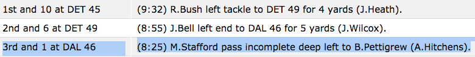

## What we did

- Three data sources
  - Armchair Analysis, Football Outsiders, stadium pictures
  - Regular season games, 2010-2014
  - Accuracy issues with NFL's PSI readings coin toss data
- Define exposure and outcome
  - \(Direction = \left\{Offensive\ Team, Defensive\ Team, Middle\right\}\)
  - Outcomes \(Y\)
    - \(Holding\) (\(OHR\))
    - \(Interference\) (\(OPI\), \(DPI\))
    - \(Aggressiveness\) (\(DAP\))

## Goals

- \(P(Y=1|Direction=Off) \stackrel{?}{=} P(Y=1|Direction=Def)\)
- Consider varying effects
- Visualize, account for uncertainty

## Frequencies

[figure not shown]

- Play Direction associated with defensive penalty calls
- Play Direction not associated with score, down/distance, etc (not shown)

## Flexible Model

- Possible moderating variable: \(LOS = Line\ of \ scrimmage\)

[figure not shown]

- Generalized additive model (GAM):
- logit(P(Y=1)) = \(\beta_1*I(Direction = Off)\) + \(f_{Off}\)(LOS) +\(f_{Def}\)(LOS)
  - \(\beta_1\)
  - \(f_{Off}(LOS), f_{Def}(LOS)\)

## Charts

[figure not shown]

## Charts

[figure not shown]

## Charts

[figure not shown]

## Charts

[figure not shown]

## Charts

[figure not shown]

## What do we know?

- More defensive judgment calls near offensive team bench
- Slightly more offensive judgment calls near defensive team bench
- Teams unaware?

## Refs - they're just like us!

They succomb to (are bullied by?) coaches & players.

[figure not shown]

## Final thoughts

- Read paper at [StatsbyLopez](http://statsbylopez.com/2015/08/05/jsm-2015)
- Acknowledgements:
  1. JSM panel
  2. Statistics in Sports section
  3. Skidmore's Cody Couture

## OPI

[figure not shown]

## DPI - random slope model

[figure not shown]